# How to update the related samplingfeatures table

# Introduction

**Sites** are a type of *sampling feature* and are uniquely identified by a unique short code (e.g. a 2-letter code identifying each wetland) as well as a computer-generated universally unique ID (uuid). We can also include a longer name, description, and spatial information.

# Set up

## Load the necessary libraries

If the library is not installed on your computer, use `install.packages()`.

```r
library(rgdal) # spatial data types
library(rgeos) # spatial
library(sf) # spatial
library(uuid) # unique ids
library(RPostgreSQL) # database
library(knitr)
library(dplyr)
library(igraph)
library(DT)
```

## Connect to the database

Use `dbConnect()` to create an object called `db` for interacting with the database. To get familiar with the database, see the document on general database interactions [Forthcoming from Kelly].

# Related Features Table

The structure of the related features table is described [here](http://odm2.github.io/ODM2/schemas/ODM2_Current/tables/ODM2SamplingFeatures_RelatedFeatures.html). The relationship type controlled vocabulary is [here](http://vocabulary.odm2.org/relationshiptype/).

The column names should match the fields in the database:

```r
dbListFields(db, c("odm2", "relatedfeatures"))
```

```
## [1] "relationid"         "samplingfeatureid"  "relationshiptypecv"
## [4] "relatedfeatureid"   "spatialoffsetid"
```

# was collected at relationship

Water samples collected at wetland sites, chamber measurements taken at a soil chamber site, etc. should be related using the “wasCollectedAt” relationship. The samples are sampling features that are type “specimen”.

# Add parent-child relationships

Because each of the soil chambers is associated with a wetland site, I will describe this as a parent-child relationship among sites, where the soil chamber sites are children of the wetland site they are at.

E.g. these are the relationships

| samplingfeature 1 | relationshiptypecv | relatedfeature |
| --- | --- | --- |
| QB SC A | isChildOf | QB |
| QB SC B | isChildOf | QB |

If there are very many sites, create this table in a spreadsheet and read it in as a dataframe.

```r
new_related_sites <- read.csv("relatedfeatures - soilchambers.csv", header = FALSE, stringsAsFactors = FALSE)
names(new_related_sites) <- c("samplingfeature", "relationshiptypecv", "relatedfeature")
new_related_sites$samplingfeature <- paste("KLH", new_related_sites$samplingfeature)
```

The names given to the columns are not the exact ones in the related features table because these are the names/codes of the sites, not their ids, which need to be gotten from the sampling features table.

Read in the sampling features table to the R environment.

```r
sites <- dbReadTable(db, c("odm2", "samplingfeatures"))
```

Join the sampling features table from the database to the dataframe with the relationships to get the IDs. This is a sequence of two joins to get the ids for the child and parent sampling features. These joins could also be done on the SQL side.

```r
new_related_sites %<>%
  left_join(sites, by = c("relatedfeature" = "samplingfeaturecode")) %>%
  dplyr::select(samplingfeature, relationshiptypecv, relatedfeature, samplingfeatureid) %>%
  rename(relatedfeatureid = samplingfeatureid) %>%
  left_join(sites, by = c("samplingfeature" = "samplingfeaturecode")) %>%
  dplyr::select(samplingfeatureid, relationshiptypecv, relatedfeatureid)
```

Update table in database

```r
dbWriteTable(db, c("odm2","relatedfeatures"),
             new_related_sites,
             overwrite = FALSE,
             row.names = FALSE,
             append = TRUE)
```

Could do the same thing more manually with SQL statements, for example this SQL code gets the sampling feature IDs for specific monitoring site codenames.

```r
sql <- "SELECT samplingfeatureid, samplingfeaturecode FROM odm2.samplingfeatures WHERE samplingfeaturecode in ('QB SC A', 'QB SC B', 'QB')"
dbGetQuery(db, sql)
```

This code is one way to view the related features table

```r
dbGetQuery(db, "SELECT * FROM odm2.relatedfeatures")
```

# Delete relationships

An example of deleting relationships

```r
sql <- "DELETE from odm2.relatedfeatures WHERE relationid >26"
dbGetQuery(db, sql)
```

See all relationships

```r
sql <- "SELECT * from odm2.relatedfeatures"
dbGetQuery(db, sql)
```

# Current site relationships

This SQL code joins the sampling features table and the related features table to show the code names of all the relationships currently in the database.

```r
sql <- "WITH t1 AS(
SELECT
  REL.samplingfeatureid,
  SF.samplingfeaturecode,
  REL.relationshiptypecv,
  REL.relatedfeatureid
FROM
  odm2.relatedfeatures REL,
  odm2.samplingfeatures SF
WHERE
  REL.samplingfeatureid = SF.samplingfeatureid)

SELECT
  t1.samplingfeaturecode,
  t1.relationshiptypecv,
  SF2.samplingfeaturecode
FROM
  t1,
  odm2.samplingfeatures SF2
WHERE
  t1.relatedfeatureid = SF2.samplingfeatureid
  "


sql <- gsub("\n", " ", sql)

related_sites <- dbGetQuery(db, sql)
```

```r
datatable(related_sites)
```

|  | samplingfeaturecode | relationshiptypecv | samplingfeaturecode |
| --- | --- | --- | --- |
| 1 | KLH QB SC D | isChildOf | QB |
| 2 | KLH QB SC B | isChildOf | QB |
| 3 | KLH QB SC C | isChildOf | QB |
| 4 | KLH QB SC E | isChildOf | QB |
| 5 | KLH QB SC A | isChildOf | QB |
| 6 | KLH JA SC C | isChildOf | JA |
| 7 | KLH JA SC B | isChildOf | JA |
| 8 | KLH JA SC A | isChildOf | JA |
| 9 | KLH BB SC E | isChildOf | BB |
| 10 | KLH BB SC D | isChildOf | BB |

[output cut: 22 more lines]

Don’t forget to disconnect at the end

```r
dbDisconnect(db)
```

# Make network graph of relations

For this we use igraph. There are many other network packages in R too.

First make a graph/network object

```r
rf <- graph_from_data_frame(related_sites[,c(1,3)], directed = TRUE)
```

Then plot it

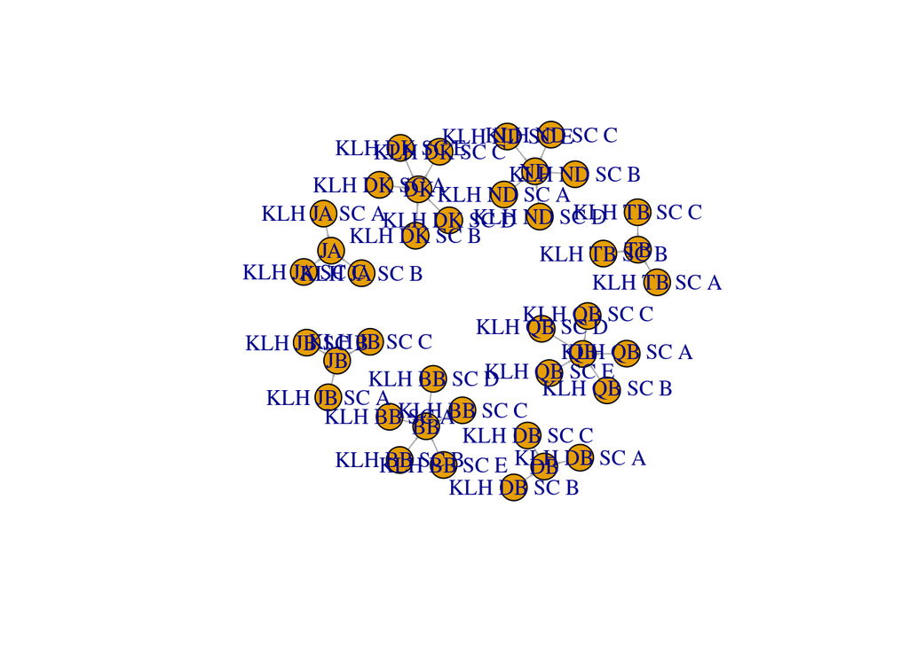

```r
plot.igraph(rf, edge.arrow.size=0.1, edge.arrow.width=0.5, arrow.mode=0)
```